# Time Series

Daniela Dias, Diogo Marto

2025-05-27

## 1. Introduction

### 1.1 Contextualization and Purpose of the Work

Technology evolves rapidly, with programming languages, frameworks, and libraries experiencing varying degrees of adoption and community interest over time. Understanding these trends is crucial for developers, educators, organizations, and technology companies to make informed decisions, such as those related to skill development and resource allocation.

Stack Overflow, as the world’s largest programming community platform, serves as an excellent proxy for measuring the popularity of technology and developer interest. The frequency of questions asked about specific technologies reflects real-world usage patterns, learning curves, and community engagement levels.

This study aims to analyze the temporal dynamics of technology usage patterns using time series analysis, with a specific focus on trends in the Python programming language. The primary objectives are:

1. **Trend Analysis**: Identify and quantify long-term growth or decline patterns in Python usage
2. **Seasonality Detection**: Discover recurring patterns that may reflect academic cycles, release schedules, or industry practices
3. **Forecasting**: Develop reliable predictive models for future Python usage trends
4. **Model Comparison**: Evaluate different time series modeling approaches to determine optimal forecasting strategies
5. **Uncertainty Quantification**: Provide confidence intervals and assess forecast reliability

The practical value of this analysis extends to multiple stakeholders: - **Educational institutions** can adjust their curriculum based on technology trends - **Technology companies** can make informed decisions about product development and support - **Individual developers** can guide career development and skill acquisition - **Researchers** can understand technology adoption patterns and community dynamics

### 1.2 Dataset Description and Source

The dataset used in this analysis was obtained from Kaggle (https://www.kaggle.com/datasets/aishu200023/stackindex) and represents a comprehensive collection of Stack Overflow question counts for various programming technologies and libraries.

**Dataset Characteristics:** - **Source**: Stack Overflow question frequency data - **Time Period**: Monthly observations from January 2009 onwards - **Granularity**: Monthly aggregated counts - **Scope**: Multiple programming languages, frameworks, and libraries - **Structure**: Each column represents a different technology (e.g., Python, R, TensorFlow, scikit-learn) - **Observations**: Each row contains question counts for all technologies in a specific month

**Key Technologies Included:** The dataset encompasses a wide range of technologies, including: - **Programming Languages**: Python, R, MATLAB - **Machine Learning Libraries**: TensorFlow, scikit-learn, Keras, PyTorch - **Data Science Tools**: pandas, NumPy, SciPy, matplotlib - **Web Frameworks**: Various Python and other web development frameworks - **Specialized Libraries**: OpenCV, NLTK, spaCy, and many others

**Data Quality Considerations:** - Monthly aggregation smooths short-term fluctuations while preserving long-term trends - Stack Overflow’s global reach provides internationally representative data - Question frequency serves as a proxy for technology usage and learning activity - The dataset reflects both professional and educational technology use patterns

### 1.3 Methodology Overview

This study employs classical time series analysis techniques following established statistical methodologies:

**1. Exploratory Data Analysis** - Time series visualization and decomposition - Stationarity testing using Augmented Dickey-Fuller (ADF) and KPSS tests - Seasonal pattern identification and quantification - Data transformation assessment using Box-Cox methodology

**2. Model Development (Box & Jenkins Methodology)** - **SARIMA Models**: Systematic identification using ACF/PACF analysis, parameter estimation, and diagnostic evaluation - **ETS Models**: Exponential smoothing with various error, trend, and seasonal components

**3. Forecast Generation and Evaluation** - Out-of-sample forecast validation using train/test split - Multiple accuracy metrics (RMSE, MAE, MAPE, MASE) - Confidence interval analysis and coverage assessment - Bootstrap methodology for non-parametric uncertainty quantification

**4. Model Comparison and Selection** - Information criteria comparison (AIC, BIC) - Forecast accuracy assessment - Diagnostic evaluation, including residual analysis - Parameter significance testing

**Focus on Python Technology Trends** While the dataset contains numerous technologies, this analysis focuses specifically on Python programming language trends due to: - Python’s significant growth in the data science and machine learning domains - Strong seasonal patterns related to academic and professional cycles - Sufficient data history for robust statistical analysis - High relevance to the current technology landscape

This methodological approach ensures rigorous statistical analysis while providing practical insights for understanding and forecasting technology adoption patterns in the programming community.

## 2. Data and exploratory analysis / data transformation

```r
library(tidyverse)
library(forecast)
library(tseries)
library(ggplot2)
library(lubridate)
library(gridExtra)
library(reshape2)
```

### 2.1 Data Loading and Initial Exploration

```r
# Load the data
data <- read.csv("data.csv")

# Display basic information about the dataset
cat("Dataset dimensions:", dim(data), "\n")
```

```
## Dataset dimensions: 132 82
```

```r
cat("Number of variables:", ncol(data) - 1, "\n")  # Excluding month column
```

```
## Number of variables: 81
```

```r
cat("Time period:", data$month[1], "to", data$month[nrow(data)], "\n")
```

```
## Time period: 09-Jan to 19-Dec
```

```r
# Show first few rows
head(data[, 1:10])  # Show first 10 columns to avoid overwhelming output
```

```
##    month nltk spacy stanford.nlp python  r numpy scipy matlab machine.learning
## 1 09-Jan    0     0            0    631  8     6     2     19                8
## 2 09-Feb    1     0            0    633  9     7     3     27                4
## 3 09-Mar    0     0            0    766  4     4     2     24                3
## 4 09-Apr    0     0            0    768 12     6     3     32               10
## 5 09-May    1     0            0   1003  2     7     2     42                7
## 6 09-Jun    0     0            0   1046  5    13     2     44                8
```

### 2.2 Data Preprocessing

```r
# Convert month column to proper date format
data$date <- as.Date(paste0("01-", data$month), format = "%d-%y-%b")

# Remove any rows with NA dates
data <- data[!is.na(data$date),]

# Sort by date
data <- data[order(data$date),]

# Print date range for verification
cat("Date range:", as.character(range(data$date)), "\n")
```

```
## Date range: 2009-01-01 2019-12-01
```

```r
# Select key technologies for analysis (focusing on major ones)
key_technologies <- c("python", "r", "machine.learning", "tensorflow",
                      "deep.learning", "time.series", "scikit.learn")

# Create a subset for focused analysis
tech_data <- data[, c("date", key_technologies)]

# Display summary statistics
summary(tech_data[, -1])
```

```
##      python            r          machine.learning   tensorflow     deep.learning    time.series
##  Min.   :  631   Min.   :   2.0   Min.   :  2.0    Min.   :   0.0   Min.   :  0.0   Min.   :  0.00
##  1st Qu.: 3744   1st Qu.: 608.8   1st Qu.: 54.0    1st Qu.:   0.0   1st Qu.:  0.0   1st Qu.: 17.75
##  Median : 9652   Median :2613.5   Median :154.5    Median :   0.0   Median :  5.0   Median : 66.00
##  Mean   : 9857   Mean   :2411.9   Mean   :264.4    Mean   : 361.1   Mean   :105.4   Mean   : 67.32
##  3rd Qu.:15591   3rd Qu.:4000.5   3rd Qu.:495.2    3rd Qu.: 970.0   3rd Qu.:234.2   3rd Qu.:105.00
##  Max.   :23602   Max.   :5138.0   Max.   :983.0    Max.   :1513.0   Max.   :500.0   Max.   :203.00
##   scikit.learn
##  Min.   :  0.0
##  1st Qu.:  1.0
##  Median : 90.5
##  Mean   :125.0
##  3rd Qu.:247.0
##  Max.   :439.0
```

### 2.3 Time Series Visualization

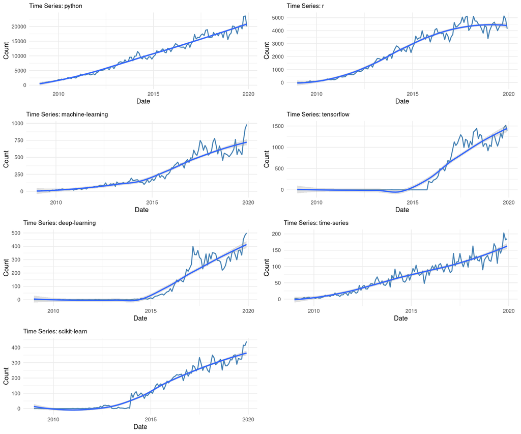

```r
# Create time series plots for key technologies
plots <- list()

for (i in 2:ncol(tech_data)) {
  tech_name <- names(tech_data)[i]

  p <- ggplot(tech_data, aes(x = date, y = .data[[tech_name]])) +
    geom_line(color = "steelblue", size = 0.8) +
    geom_smooth(method = "loess", se = TRUE, alpha = 0.3) +
    labs(title = paste("Time Series:", str_replace_all(tech_name, "\\.", "-")),
         x = "Date", y = "Count") +
    theme_minimal() +
    theme(plot.title = element_text(size = 10))

  plots[[tech_name]] <- p
}

# Arrange plots in a grid
if (length(plots) > 0) {
  do.call(grid.arrange, c(plots, ncol = 2))
} else {
  cat("No plots to display - check data processing\n")
}
```

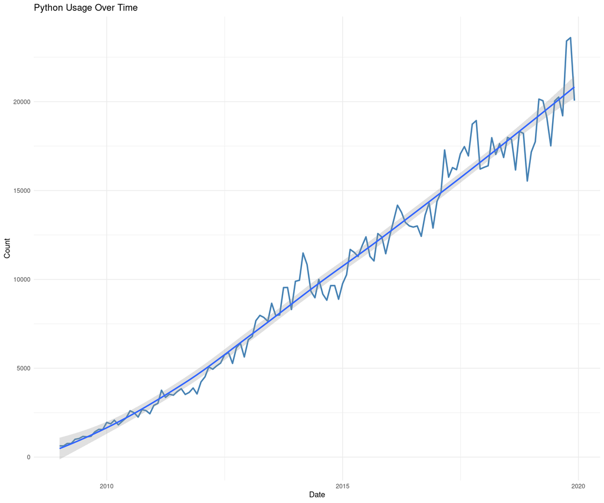

```r
# Plot Python usage specifically
python_plot <- ggplot(tech_data, aes(x = date, y = python)) +
  geom_line(color = "steelblue", size = 1) +
  geom_smooth(method = "loess", se = TRUE, alpha = 0.3) +
  labs(title = "Python Usage Over Time",
       x = "Date", y = "Count") +
  theme_minimal()
print(python_plot)
```

### 2.4 Box-Cox

```r
lambda_bc <- BoxCox.lambda(python_ts)
cat("Optimal Box-Cox lambda:", lambda_bc, "\n")
```

```
## Optimal Box-Cox lambda: 0.4195015
```

```
## Box-Cox transformation applied using lambda: 0.4195015
```

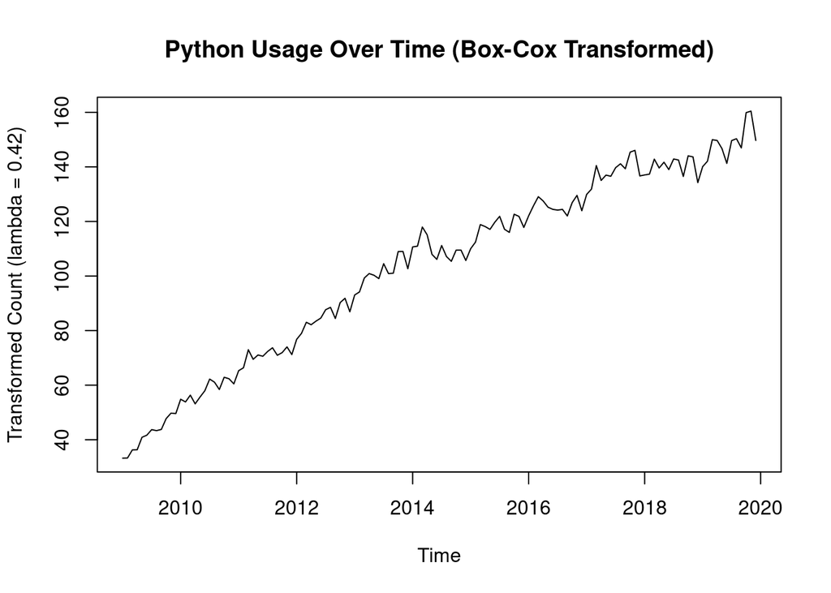

```r
# Apply Box-Cox transformation using the estimated lambda.
# We apply it only if the lambda suggests a significant transformation
# (i.e., not very close to 1). Small deviations might not warrant a transform.
# For demonstration, we will apply it if lambda is not exactly 1 or 0.
# If lambda is 0, BoxCox() automatically applies log transformation.
if (abs(lambda_bc - 1) > 0.01) { # Apply if lambda is not very close to 1
  python_ts_transformed <- BoxCox(python_ts, lambda = lambda_bc)
  cat("Box-Cox transformation applied using lambda:", lambda_bc, "\n")
  # Plot the transformed series to visually inspect variance stabilization
  plot(python_ts_transformed, main = "Python Usage Over Time (Box-Cox Transformed)",
       ylab = paste0("Transformed Count (lambda = ", round(lambda_bc, 2), ")"))

  # Update python_ts to the transformed series for subsequent steps
  # This ensures all following analyses use the variance-stabilized data.
  python_ts <- python_ts_transformed
} else {
  cat("No significant Box-Cox transformation needed (lambda close to 1, or series already stable).\n")
  # If no transformation is applied, python_ts remains as it was initialized.
}
```

### 2.5 Trend and Seasonality Analysis

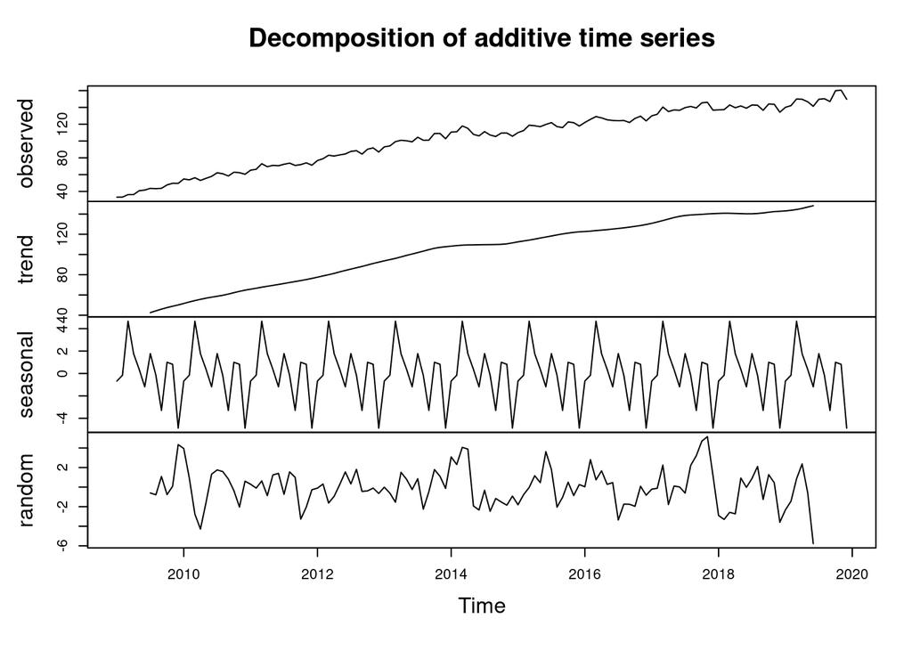

```r
# Focus on Python as main technology for detailed analysis
# python_ts <- ts(data$python, start = c(2009, 1), frequency = 12)

# Decompose the time series
python_decomp <- decompose(python_ts)

# Plot decomposition
plot(python_decomp)
```

```r
# Calculate trend statistics
cat("Python usage trend analysis:\n")
```

```
## Python usage trend analysis:
```

```r
cat("Mean:", mean(python_ts), "\n")
```

```
## Mean: 103.3707
```

```r
cat("Standard deviation:", sd(python_ts), "\n")
```

```
## Standard deviation: 34.26465
```

```r
cat("Coefficient of variation:", sd(python_ts) / mean(python_ts), "\n")
```

```
## Coefficient of variation: 0.3314735
```

### 2.6 Stationarity Testing

```r
# Augmented Dickey-Fuller test for stationarity
adf_test <- adf.test(python_ts)
cat("ADF Test for Python time series:\n")
```

```
## ADF Test for Python time series:
```

```r
cat("Test statistic:", adf_test$statistic, "\n")
```

```
## Test statistic: -2.106813
```

```r
cat("p-value:", adf_test$p.value, "\n")
```

```
## p-value: 0.5320837
```

```r
cat("Result:", ifelse(adf_test$p.value < 0.05, "Stationary", "Non-stationary"), "\n\n")
```

```
## Result: Non-stationary
```

```r
# KPSS test
kpss_test <- kpss.test(python_ts)
cat("KPSS Test for Python time series:\n")
```

```
## KPSS Test for Python time series:
```

```r
cat("Test statistic:", kpss_test$statistic, "\n")
```

```
## Test statistic: 2.679136
```

```r
cat("p-value:", kpss_test$p.value, "\n")
```

```
## p-value: 0.01
```

```r
cat("Result:", ifelse(kpss_test$p.value < 0.05, "Stationary", "Non-stationary"), "\n")
```

```
## Result: Stationary
```

### 2.7 Differencing Analysis

```r
# First create the differenced series
python_diff <- diff(python_ts)

# Test stationarity of regular differenced series
adf_diff <- adf.test(python_diff)
cat("=== COMPREHENSIVE DIFFERENCING ANALYSIS ===\n\n")
```

```
## === COMPREHENSIVE DIFFERENCING ANALYSIS ===
```

```r
cat("Regular differencing (first difference) results:\n")
```

```
## Regular differencing (first difference) results:
```

```r
cat("ADF test p-value:", adf_diff$p.value, "\n")
```

```
## ADF test p-value: 0.01
```

```r
cat("Result:", ifelse(adf_diff$p.value < 0.05, "Stationary", "Non-stationary"), "\n\n")
```

```
## Result: Stationary
```

```r
# Apply seasonal differencing (difference at lag 12 for monthly data)
python_seasonal_diff <- diff(python_ts, lag = 12)

# Test stationarity of seasonally differenced series
cat("Seasonal differencing (lag 12) results:\n")
```

```
## Seasonal differencing (lag 12) results:
```

```r
adf_seasonal <- adf.test(python_seasonal_diff)
cat("ADF test p-value:", adf_seasonal$p.value, "\n")
```

```
## ADF test p-value: 0.2061843
```

```r
cat("Result:", ifelse(adf_seasonal$p.value < 0.05, "Stationary", "Non-stationary"), "\n\n")
```

```
## Result: Non-stationary
```

```r
# Apply both seasonal and regular differencing simultaneously
# This is the standard approach for seasonal time series
python_both_diff <- diff(diff(python_ts, lag = 12))

cat("Both seasonal and regular differencing:\n")
```

```
## Both seasonal and regular differencing:
```

```r
adf_both <- adf.test(python_both_diff)
cat("ADF test p-value:", adf_both$p.value, "\n")
```

```
## ADF test p-value: 0.01
```

```r
cat("Result:", ifelse(adf_both$p.value < 0.05, "Stationary", "Non-stationary"), "\n\n")
```

```
## Result: Stationary
```

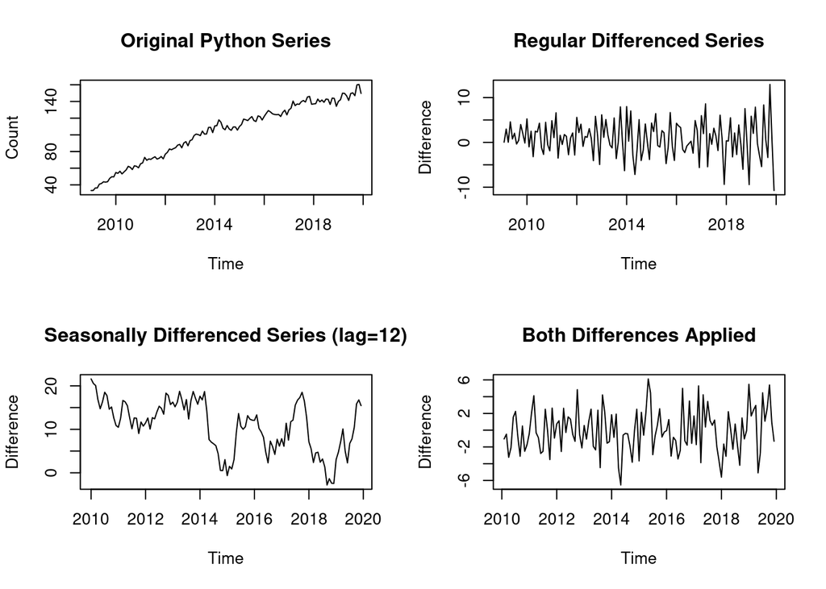

```r
# Plot all differencing approaches
par(mfrow = c(2, 2))
plot(python_ts, main = "Original Python Series", ylab = "Count")
plot(python_diff, main = "Regular Differenced Series", ylab = "Difference")
plot(python_seasonal_diff, main = "Seasonally Differenced Series (lag=12)", ylab = "Difference")
plot(python_both_diff, main = "Both Differences Applied", ylab = "Difference")
```

```r
par(mfrow = c(1, 1))
```

### 2.8 Data Splitting for Model Development

```r
# Calculate split point (80% for training, 20% for testing)
python_ts <- ts(data$python, start = c(2009, 1), frequency = 12)
total_obs <- length(python_ts)
train_size <- floor(0.8 * total_obs)

# Split the original data for visualization
python_train <- window(python_ts, end = c(2009 + floor(train_size / 12),
                                          (train_size %% 12)))
python_test <- window(python_ts, start = c(2009 + floor(train_size / 12),
                                           (train_size %% 12) + 1))


cat("Training set length:", length(python_train), "\n")
```

```
## Training set length: 105
```

```r
cat("Test set length:", length(python_test), "\n")
```

```
## Test set length: 27
```

```r
cat("Training period:", start(python_train), "to", end(python_train), "\n")
```

```
## Training period: 2009 1 to 2017 9
```

```r
cat("Test period:", start(python_test), "to", end(python_test), "\n")
```

```
## Test period: 2017 10 to 2019 12
```

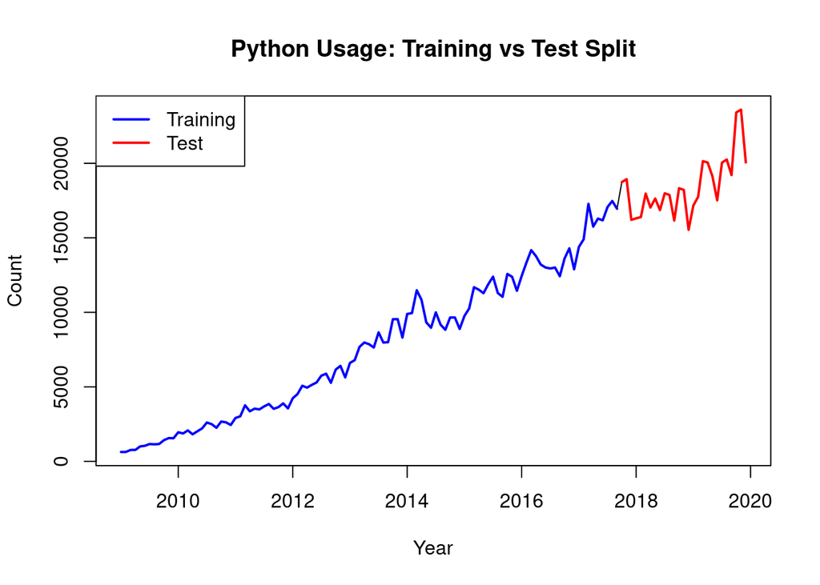

```r
# Plot the split
plot(python_ts, main = "Python Usage: Training vs Test Split",
     ylab = "Count", xlab = "Year")
lines(python_train, col = "blue", lwd = 2)
lines(python_test, col = "red", lwd = 2)
legend("topleft", legend = c("Training", "Test"),
       col = c("blue", "red"), lwd = 2)
```

## 3. Model proposals

### 3.1 SARIMA Model Development (Box & Jenkins Methodology)

#### 3.1.1 Model Identification

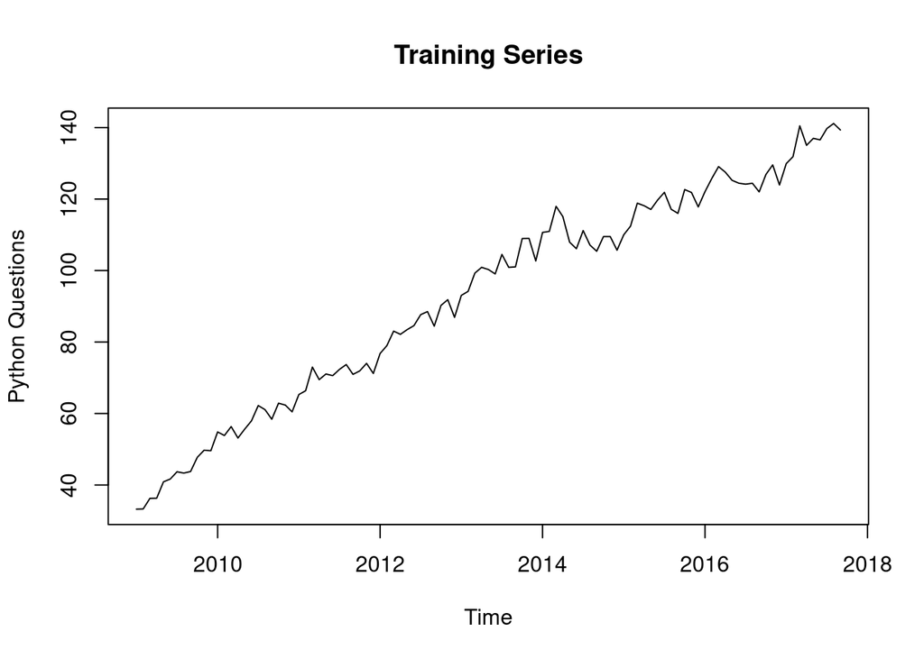

```r
# Use original training data for model development
train_ts <- python_train
train_ts <- BoxCox(train_ts, lambda = lambda_bc)

# Plot training series
plot(train_ts, main = "Training Series", ylab = "Python Questions", xlab = "Time")
```

```r
# Check stationarity of training series
adf_train <- adf.test(train_ts)
cat("ADF test p-value for training series:", adf_train$p.value, "\n")
```

```
## ADF test p-value for training series: 0.4481163
```

```r
cat("Training series is:", ifelse(adf_train$p.value < 0.05, "Stationary", "Non-stationary"), "\n\n")
```

```
## Training series is: Non-stationary
```

```r
# Create differenced series from training data for model identification
cat("=== ACF/PACF ANALYSIS FOR MODEL IDENTIFICATION ===\n\n")
```

```
## === ACF/PACF ANALYSIS FOR MODEL IDENTIFICATION ===
```

```r
train_diff <- diff(train_ts)
train_seasonal_diff <- diff(train_ts, lag = 12)
train_both_diff <- diff(diff(train_ts, lag = 12))

# Test stationarity of differenced training series
cat("Stationarity tests on training data:\n")
```

```
## Stationarity tests on training data:
```

```r
cat("- Regular differenced: p-value =", adf.test(train_diff)$p.value, "\n")
```

```
## - Regular differenced: p-value = 0.01
```

```r
cat("- Seasonal differenced: p-value =", adf.test(train_seasonal_diff)$p.value, "\n")
```

```
## - Seasonal differenced: p-value = 0.529372
```

```r
cat("- Both differences: p-value =", adf.test(train_both_diff)$p.value, "\n\n")
```

```
## - Both differences: p-value = 0.01691072
```

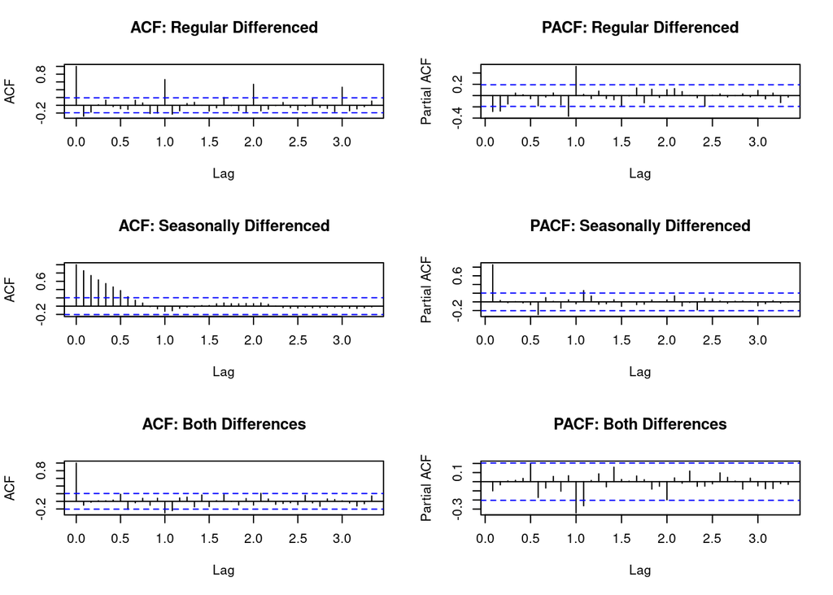

```r
# ACF/PACF plots for model identification
par(mfrow = c(3, 2))

# Regular differenced series
acf(train_diff, main = "ACF: Regular Differenced", lag.max = 40, na.action = na.pass)
pacf(train_diff, main = "PACF: Regular Differenced", lag.max = 40, na.action = na.pass)

# Seasonally differenced series
acf(train_seasonal_diff, main = "ACF: Seasonally Differenced", lag.max = 40, na.action = na.pass)
pacf(train_seasonal_diff, main = "PACF: Seasonally Differenced", lag.max = 40, na.action = na.pass)

# Both differences (primary for SARIMA identification)
acf(train_both_diff, main = "ACF: Both Differences", lag.max = 40, na.action = na.pass)
pacf(train_both_diff, main = "PACF: Both Differences", lag.max = 40, na.action = na.pass)
```

```r
par(mfrow = c(1, 1))

cat("Model Identification Guidelines:\n")
```

```
## Model Identification Guidelines:
```

```r
cat("- Use 'Both Differences' series for SARIMA parameter identification\n")
```

```
## - Use 'Both Differences' series for SARIMA parameter identification
```

```r
cat("- Look for patterns in ACF/PACF at seasonal lags (12, 24, 36...)\n")
```

```
## - Look for patterns in ACF/PACF at seasonal lags (12, 24, 36...)
```

```r
cat("- Consider d=1, D=1 based on differencing analysis\n")
```

```
## - Consider d=1, D=1 based on differencing analysis
```

#### 3.1.2 Manual Model Comparison

```r
# Define candidate SARIMA models based on ACF/PACF analysis
models_to_test <- list(
  list(order = c(1, 1, 0), seasonal = c(1, 1, 1)),
  list(order = c(1, 1, 0), seasonal = c(0, 1, 1)),
  list(order = c(1, 1, 0), seasonal = c(1, 1, 0)),
  list(order = c(1, 1, 0), seasonal = c(1, 0, 0)),
  list(order = c(1, 1, 0), seasonal = c(0, 0, 1)),
  list(order = c(0, 1, 1), seasonal = c(0, 0, 0)),
  list(order = c(1, 1, 1), seasonal = c(1, 1, 1)),
  list(order = c(1, 1, 1), seasonal = c(0, 1, 1)),
  list(order = c(1, 1, 1), seasonal = c(1, 1, 0)),
  list(order = c(1, 1, 1), seasonal = c(1, 0, 0)),
  list(order = c(1, 1, 1), seasonal = c(0, 0, 1)),
  list(order = c(0, 1, 2), seasonal = c(0, 0, 0))
)

# Store model results
model_results <- data.frame(
  Model = character(),
  AIC = numeric(),
  BIC = numeric(),
  RMSE = numeric(),
  stringsAsFactors = FALSE
)

cat("Testing candidate SARIMA models:\n")
```

```
## Testing candidate SARIMA models:
```

```r
for (i in 1:length(models_to_test)) {
  tryCatch({
    model <- Arima(train_ts,
                   order = models_to_test[[i]]$order,
                   seasonal = models_to_test[[i]]$seasonal)

    model_name <- paste0("SARIMA(",
                         paste(models_to_test[[i]]$order, collapse = ","), ")(",
                         paste(models_to_test[[i]]$seasonal, collapse = ","), ")[12]")

    # Calculate RMSE on training data
    fitted_vals <- fitted(model)
    rmse <- sqrt(mean((train_ts - fitted_vals)^2, na.rm = TRUE))

    model_results <- rbind(model_results, data.frame(
      Model = model_name,
      AIC = model$aic,
      BIC = model$bic,
      RMSE = rmse
    ))

    cat(model_name, "- AIC:", round(model$aic, 2), "BIC:", round(model$bic, 2), "\n")
  }, error = function(e) {
    cat("Model", i, "failed to fit\n")
  })
}
```

```
## SARIMA(1,1,0)(1,1,1)[12] - AIC: 416.48 BIC: 426.57
## SARIMA(1,1,0)(0,1,1)[12] - AIC: 415.66 BIC: 423.23
## SARIMA(1,1,0)(1,1,0)[12] - AIC: 422.47 BIC: 430.04
## SARIMA(1,1,0)(1,0,0)[12] - AIC: 486.72 BIC: 494.66
## SARIMA(1,1,0)(0,0,1)[12] - AIC: 520.67 BIC: 528.6
## SARIMA(0,1,1)(0,0,0)[12] - AIC: 560.3 BIC: 565.59
## SARIMA(1,1,1)(1,1,1)[12] - AIC: 417.78 BIC: 430.38
## SARIMA(1,1,1)(0,1,1)[12] - AIC: 416.85 BIC: 426.94
## SARIMA(1,1,1)(1,1,0)[12] - AIC: 424.09 BIC: 434.18
## Model 10 failed to fit
## SARIMA(1,1,1)(0,0,1)[12] - AIC: 522.64 BIC: 533.22
## SARIMA(0,1,2)(0,0,0)[12] - AIC: 562.27 BIC: 570.2
```

```r
# Display results sorted by AIC
model_results <- model_results[order(model_results$AIC),]
print(model_results)
```

```
##                       Model      AIC      BIC     RMSE
## 2  SARIMA(1,1,0)(0,1,1)[12] 415.6622 423.2276 2.036732
## 1  SARIMA(1,1,0)(1,1,1)[12] 416.4838 426.5710 1.983079
## 8  SARIMA(1,1,1)(0,1,1)[12] 416.8517 426.9389 2.022286
## 7  SARIMA(1,1,1)(1,1,1)[12] 417.7750 430.3840 1.968553
## 3  SARIMA(1,1,0)(1,1,0)[12] 422.4711 430.0365 2.155545
## 9  SARIMA(1,1,1)(1,1,0)[12] 424.0896 434.1768 2.149987
## 4  SARIMA(1,1,0)(1,0,0)[12] 486.7231 494.6563 2.315466
## 5  SARIMA(1,1,0)(0,0,1)[12] 520.6711 528.6042 2.791329
## 10 SARIMA(1,1,1)(0,0,1)[12] 522.6387 533.2162 2.791406
## 6  SARIMA(0,1,1)(0,0,0)[12] 560.3013 565.5901 3.492496
## 11 SARIMA(0,1,2)(0,0,0)[12] 562.2674 570.2006 3.491963
```

#### 3.1.3 Automatic Model Selection

```r
# Use auto.arima for SARIMA model selection
auto_sarima <- auto.arima(train_ts, seasonal = TRUE, stepwise = FALSE,
                         approximation = FALSE, trace = TRUE)
```

```
##
##  ARIMA(0,1,0)(0,1,0)[12]                    : 431.6875
##  ARIMA(0,1,0)(0,1,1)[12]                    : 416.0422
##  ARIMA(0,1,0)(0,1,2)[12]                    : 415.99
##  ARIMA(0,1,0)(1,1,0)[12]                    : 423.705
##  ARIMA(0,1,0)(1,1,1)[12]                    : Inf
##  ARIMA(0,1,0)(1,1,2)[12]                    : Inf
##  ARIMA(0,1,0)(2,1,0)[12]                    : 420.6265
##  ARIMA(0,1,0)(2,1,1)[12]                    : Inf
##  ARIMA(0,1,0)(2,1,2)[12]                    : Inf
##  ARIMA(0,1,1)(0,1,0)[12]                    : 432.8181
##  ARIMA(0,1,1)(0,1,1)[12]                    : 415.3765
##  ARIMA(0,1,1)(0,1,2)[12]                    : 416.7069
##  ARIMA(0,1,1)(1,1,0)[12]                    : 422.3745
##  ARIMA(0,1,1)(1,1,1)[12]                    : 416.6123
##  ARIMA(0,1,1)(1,1,2)[12]                    : Inf
##  ARIMA(0,1,1)(2,1,0)[12]                    : 420.0818
##  ARIMA(0,1,1)(2,1,1)[12]                    : 418.8059
##  ARIMA(0,1,1)(2,1,2)[12]                    : Inf
##  ARIMA(0,1,2)(0,1,0)[12]                    : 434.9201
##  ARIMA(0,1,2)(0,1,1)[12]                    : 416.9599
##  ARIMA(0,1,2)(0,1,2)[12]                    : 418.1133
##  ARIMA(0,1,2)(1,1,0)[12]                    : 424.5375
##  ARIMA(0,1,2)(1,1,1)[12]                    : 418.0303
##  ARIMA(0,1,2)(1,1,2)[12]                    : Inf
##  ARIMA(0,1,2)(2,1,0)[12]                    : 422.1713
##  ARIMA(0,1,2)(2,1,1)[12]                    : Inf
##  ARIMA(0,1,3)(0,1,0)[12]                    : 437.0748
##  ARIMA(0,1,3)(0,1,1)[12]                    : 418.3003
##  ARIMA(0,1,3)(0,1,2)[12]                    : 419.9724
##  ARIMA(0,1,3)(1,1,0)[12]                    : 426.0649
##  ARIMA(0,1,3)(1,1,1)[12]                    : 419.9478
##  ARIMA(0,1,3)(2,1,0)[12]                    : 423.1684
##  ARIMA(0,1,4)(0,1,0)[12]                    : 439.1406
##  ARIMA(0,1,4)(0,1,1)[12]                    : 420.5792
##  ARIMA(0,1,4)(1,1,0)[12]                    : 428.3459
##  ARIMA(0,1,5)(0,1,0)[12]                    : 440.9785
##  ARIMA(1,1,0)(0,1,0)[12]                    : 432.8704
##  ARIMA(1,1,0)(0,1,1)[12]                    : 415.935
##  ARIMA(1,1,0)(0,1,2)[12]                    : 417.0515
```

[output cut: 46 more lines]

```
##  ARIMA(3,1,0)(1,1,1)[12]                    : 419.9364
##  ARIMA(3,1,0)(2,1,0)[12]                    : 422.4291
##  ARIMA(3,1,1)(0,1,0)[12]                    : 439.2202
##  ARIMA(3,1,1)(0,1,1)[12]                    : 420.2123
##  ARIMA(3,1,1)(1,1,0)[12]                    : 428.2262
##  ARIMA(3,1,2)(0,1,0)[12]                    : Inf
##  ARIMA(4,1,0)(0,1,0)[12]                    : 439.3037
##  ARIMA(4,1,0)(0,1,1)[12]                    : 419.9223
##  ARIMA(4,1,0)(1,1,0)[12]                    : 427.6968
##  ARIMA(4,1,1)(0,1,0)[12]                    : 441.196
##  ARIMA(5,1,0)(0,1,0)[12]                    : 441.4617
##
##
##
##  Best model: ARIMA(0,1,1)(0,1,1)[12]
```

```r
cat("Auto-selected SARIMA model:\n")
```

```
## Auto-selected SARIMA model:
```

```r
print(auto_sarima)
```

```
## Series: train_ts
## ARIMA(0,1,1)(0,1,1)[12]
##
## Coefficients:
##           ma1     sma1
##       -0.1892  -0.6144
## s.e.   0.1082   0.1255
##
## sigma^2 = 4.8:  log likelihood = -204.55
## AIC=415.1   AICc=415.38   BIC=422.67
```

```r
# Use auto.arima for non-seasonal ARIMA model selection
auto_arima <- auto.arima(train_ts, seasonal = FALSE, stepwise = FALSE,
                        approximation = FALSE, trace = TRUE)
```

```
##
##  ARIMA(0,1,0)                               : 562.0857
##  ARIMA(0,1,0)            with drift         : 555.3289
##  ARIMA(0,1,1)                               : 560.4201
##  ARIMA(0,1,1)            with drift         : 541.8409
##  ARIMA(0,1,2)                               : 562.5074
##  ARIMA(0,1,2)            with drift         : 541.6721
##  ARIMA(0,1,3)                               : 560.8748
##  ARIMA(0,1,3)            with drift         : 543.8091
##  ARIMA(0,1,4)                               : 558.3133
##  ARIMA(0,1,4)            with drift         : 546.0336
##  ARIMA(0,1,5)                               : 560.4405
##  ARIMA(0,1,5)            with drift         : 546.1118
##  ARIMA(1,1,0)                               : 560.9482
##  ARIMA(1,1,0)            with drift         : 548.8681
##  ARIMA(1,1,1)                               : 562.5283
##  ARIMA(1,1,1)            with drift         : 542.1191
##  ARIMA(1,1,2)                               : 564.4663
##  ARIMA(1,1,2)            with drift         : 543.8333
##  ARIMA(1,1,3)                               : 559.7432
##  ARIMA(1,1,3) with drift         : Inf
##  ARIMA(1,1,4)                               : 560.4511
##  ARIMA(1,1,4) with drift         : Inf
##  ARIMA(2,1,0)                               : 561.7589
##  ARIMA(2,1,0)            with drift         : 542.9312
##  ARIMA(2,1,1)                               : 563.8456
##  ARIMA(2,1,1)            with drift         : 543.5029
##  ARIMA(2,1,2)                               : Inf
##  ARIMA(2,1,2)            with drift         : 545.4762
##  ARIMA(2,1,3)                               : Inf
##  ARIMA(2,1,3)            with drift         : Inf
##  ARIMA(3,1,0)                               : 563.5595
##  ARIMA(3,1,0)            with drift         : 542.881
##  ARIMA(3,1,1)                    : Inf
##  ARIMA(3,1,1)            with drift         : 544.9862
##  ARIMA(3,1,2)                    : Inf
##  ARIMA(3,1,2)            with drift         : Inf
##  ARIMA(4,1,0)                               : 560.3231
##  ARIMA(4,1,0)            with drift         : 544.9407
##  ARIMA(4,1,1)                               : Inf
##  ARIMA(4,1,1)            with drift         : 547.2364
##  ARIMA(5,1,0)                               : 559.9415
##  ARIMA(5,1,0)            with drift         : 547.2203
##
##
##
##  Best model: ARIMA(0,1,2)            with drift
```

```r
cat("\nAuto-selected ARIMA (non-seasonal) model:\n")
```

```
##
## Auto-selected ARIMA (non-seasonal) model:
```

```r
print(auto_arima)
```

```
## Series: train_ts
## ARIMA(0,1,2) with drift
##
## Coefficients:
##           ma1      ma2   drift
##       -0.3941  -0.1614  1.0253
## s.e.   0.0976   0.1019  0.1390
##
## sigma^2 = 10.14:  log likelihood = -266.63
## AIC=541.27   AICc=541.67   BIC=551.85
```

```r
# Compare SARIMA vs ARIMA
cat("\n=== AUTOMATIC MODEL COMPARISON ===\n")
```

```
##
## === AUTOMATIC MODEL COMPARISON ===
```

```r
cat("SARIMA Model:\n")
```

```
## SARIMA Model:
```

```r
cat("- Model:", paste(arimaorder(auto_sarima), collapse = "-"), "\n")
```

```
## - Model: 0-1-1-0-1-1-12
```

```r
cat("- AIC:", auto_sarima$aic, "\n")
```

```
## - AIC: 415.1038
```

```r
cat("- BIC:", auto_sarima$bic, "\n")
```

```
## - BIC: 422.6691
```

```r
cat("\nARIMA Model:\n")
```

```
##
## ARIMA Model:
```

```r
cat("- Model:", paste(arimaorder(auto_arima)[1:3], collapse = "-"), "\n")
```

```
## - Model: 0-1-2
```

```r
cat("- AIC:", auto_arima$aic, "\n")
```

```
## - AIC: 541.2681
```

```r
cat("- BIC:", auto_arima$bic, "\n")
```

```
## - BIC: 551.8456
```

```r
# Determine which automatic model is better
if (auto_sarima$aic < auto_arima$aic) {
  best_auto_model <- auto_sarima
  cat("\nBest automatic model: SARIMA (lower AIC)\n")
} else {
  best_auto_model <- auto_arima
  cat("\nBest automatic model: ARIMA (lower AIC)\n")
}
```

```
##
## Best automatic model: SARIMA (lower AIC)
```

```r
cat("\nModel summary for best automatic model:\n")
```

```
##
## Model summary for best automatic model:
```

```r
summary(best_auto_model)
```

```
## Series: train_ts
## ARIMA(0,1,1)(0,1,1)[12]
##
## Coefficients:
##           ma1     sma1
##       -0.1892  -0.6144
## s.e.   0.1082   0.1255
##
## sigma^2 = 4.8:  log likelihood = -204.55
## AIC=415.1   AICc=415.38   BIC=422.67
##
## Training set error measures:
##                      ME     RMSE     MAE        MPE     MAPE      MASE        ACF1
## Training set -0.2025407 2.028467 1.50685 -0.3134057 1.596552 0.1258924 0.001819536
```

#### 3.1.4 Parameter Estimation and Significance

```r
# Use best automatic model for detailed analysis
best_sarima <- best_auto_model

cat("Best model coefficients:\n")
```

```
## Best model coefficients:
```

```r
print(coef(best_sarima))
```

```
##        ma1       sma1
## -0.1891616 -0.6143749
```

```r
cat("\nStandard errors:\n")
```

```
##
## Standard errors:
```

```r
print(sqrt(diag(best_sarima$var.coef)))
```

```
##       ma1      sma1
## 0.1081752 0.1254531
```

```r
cat("\nT-statistics:\n")
```

```
##
## T-statistics:
```

```r
t_stats <- coef(best_sarima) / sqrt(diag(best_sarima$var.coef))
print(t_stats)
```

```
##       ma1      sma1
## -1.748659 -4.897249
```

```r
cat("\nP-values:\n")
```

```
##
## P-values:
```

```r
p_values <- 2 * (1 - pnorm(abs(t_stats)))
print(p_values)
```

```
##          ma1         sma1
## 8.034992e-02 9.718753e-07
```

```r
# Parameter significance (p < 0.05)
significant_params <- p_values < 0.05
cat("\nSignificant parameters (p < 0.05):\n")
```

```
##
## Significant parameters (p < 0.05):
```

```r
print(significant_params)
```

```
##   ma1  sma1
## FALSE  TRUE
```

```r
# Model type identification
if (length(arimaorder(best_sarima)) == 6) {
  cat("\nSelected model type: SARIMA\n")
  cat("Model specification:", paste(arimaorder(best_sarima), collapse = "-"), "\n")
} else {
  cat("\nSelected model type: ARIMA (non-seasonal)\n")
  cat("Model specification:", paste(arimaorder(best_sarima)[1:3], collapse = "-"), "\n")
}
```

```
##
## Selected model type: ARIMA (non-seasonal)
## Model specification: 0-1-1
```

#### 3.1.5 Diagnostic Evaluation

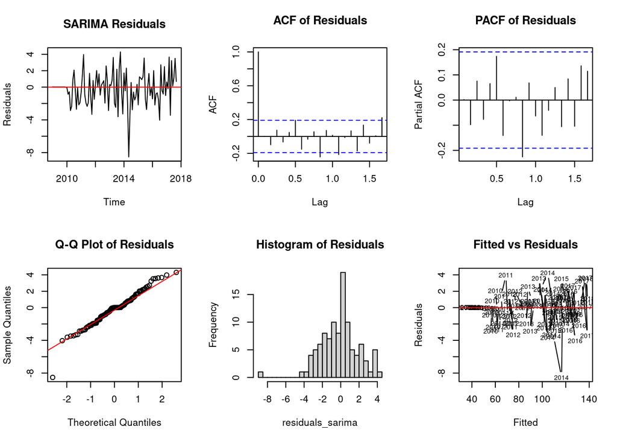

```r
# Residual analysis
residuals_sarima <- residuals(best_sarima)

par(mfrow = c(2, 3))
# 1. Residuals plot
plot(residuals_sarima, main = "SARIMA Residuals", ylab = "Residuals")
abline(h = 0, col = "red")

# 2. ACF of residuals
acf(residuals_sarima, main = "ACF of Residuals", na.action = na.pass)

# 3. PACF of residuals
pacf(residuals_sarima, main = "PACF of Residuals", na.action = na.pass)

# 4. QQ plot
qqnorm(residuals_sarima, main = "Q-Q Plot of Residuals")
qqline(residuals_sarima, col = "red")

# 5. Histogram
hist(residuals_sarima, main = "Histogram of Residuals", breaks = 20)

# 6. Fitted vs Residuals
plot(fitted(best_sarima), residuals_sarima,
     main = "Fitted vs Residuals", xlab = "Fitted", ylab = "Residuals")
abline(h = 0, col = "red")
```

```r
par(mfrow = c(1, 1))

# Statistical tests for residuals
cat("Ljung-Box test for residual autocorrelation:\n")
```

```
## Ljung-Box test for residual autocorrelation:
```

```r
lb_test <- Box.test(residuals_sarima, lag = 20, type = "Ljung-Box")
print(lb_test)
```

```
##
##  Box-Ljung test
##
## data:  residuals_sarima
## X-squared = 36.623, df = 20, p-value = 0.01298
```

### 3.2 ETS Model Development

#### 3.2.1 Manual ETS Model Selection

```r
# Manual ETS models - using valid combinations
train_ts <- python_train # this is in BoxCox for SARIMA model on this model since the best Model has Error M this doesnt matter
cat("Fitting ETS models:\n")
```

```
## Fitting ETS models:
```

```r
ets_models <- list()

# Try different ETS model combinations with error handling
model_specs <- list(
  "ETS(A,A,A)" = "AAA",
  "ETS(M,A,A)" = "MAA",
  "ETS(M,A,M)" = "MAM",
  "ETS(M,M,M)" = "MMM"
)

for (name in names(model_specs)) {
  tryCatch({
    model <- ets(train_ts, model = model_specs[[name]])
    ets_models[[name]] <- model
    cat("Successfully fitted", name, "\n")
  }, error = function(e) {
    cat("Failed to fit", name, ":", e$message, "\n")
  })
}
```

```
## Successfully fitted ETS(A,A,A)
## Successfully fitted ETS(M,A,A)
## Successfully fitted ETS(M,A,M)
## Successfully fitted ETS(M,M,M)
```

```r
# Compare manual ETS models
ets_manual_comparison <- data.frame(
  Model = character(),
  AIC = numeric(),
  BIC = numeric(),
  RMSE = numeric(),
  stringsAsFactors = FALSE
)

# Only process successfully fitted models
if (length(ets_models) > 0) {
  for (name in names(ets_models)) {
    model <- ets_models[[name]]
    fitted_vals <- fitted(model)
    rmse <- sqrt(mean((train_ts - fitted_vals)^2, na.rm = TRUE))

    ets_manual_comparison <- rbind(ets_manual_comparison, data.frame(
      Model = name,
      AIC = model$aic,
      BIC = model$bic,
      RMSE = rmse
    ))
  }

  ets_manual_comparison <- ets_manual_comparison[order(ets_manual_comparison$AIC),]
  print(ets_manual_comparison)
} else {
  cat("No manual ETS models fitted successfully\n")
}
```

```
##        Model      AIC      BIC     RMSE
## 3 ETS(M,A,M) 1718.381 1766.152 374.2880
## 4 ETS(M,M,M) 1721.536 1769.307 386.7047
## 1 ETS(A,A,A) 1795.686 1840.804 429.2338
## 2 ETS(M,A,A) 1901.583 1949.354 601.8613
```

#### 3.2.2 Automatic ETS Model Selection

```r
# Automatic ETS model selection
ets_auto <- ets(train_ts)
cat("Auto-selected ETS model:\n")
```

```
## Auto-selected ETS model:
```

```r
print(ets_auto)
```

```
## ETS(M,Ad,M)
##
## Call:
## ets(y = train_ts)
##
##   Smoothing parameters:
##     alpha = 0.7452
##     beta  = 0.0571
##     gamma = 1e-04
##     phi   = 0.9799
##
##   Initial states:
##     l = 447.1339
##     b = 134.5046
##     s = 0.8902 1.0025 1.0081 0.9147 0.9842 1.0346
##            0.9885 1.0159 1.0238 1.1137 1.007 1.0168
##
##   sigma:  0.0568
##
##      AIC     AICc      BIC
## 1718.381 1726.335 1766.152
```

```r
# Calculate RMSE for auto model
fitted_auto <- fitted(ets_auto)
rmse_auto <- sqrt(mean((train_ts - fitted_auto)^2, na.rm = TRUE))

cat("Auto ETS model performance:\n")
```

```
## Auto ETS model performance:
```

```r
cat("AIC:", ets_auto$aic, "\n")
```

```
## AIC: 1718.381
```

```r
cat("BIC:", ets_auto$bic, "\n")
```

```
## BIC: 1766.152
```

```r
cat("RMSE:", rmse_auto, "\n")
```

```
## RMSE: 374.288
```

```r
# Compare all ETS models (manual + auto)
ets_comparison <- ets_manual_comparison
ets_comparison <- rbind(ets_comparison, data.frame(
  Model = "ETS(Auto)",
  AIC = ets_auto$aic,
  BIC = ets_auto$bic,
  RMSE = rmse_auto
))

ets_comparison <- ets_comparison[order(ets_comparison$AIC),]
cat("\nAll ETS models comparison:\n")
```

```
##
## All ETS models comparison:
```

```r
print(ets_comparison)
```

```
##         Model      AIC      BIC     RMSE
## 3  ETS(M,A,M) 1718.381 1766.152 374.2880
## 11  ETS(Auto) 1718.381 1766.152 374.2880
## 4  ETS(M,M,M) 1721.536 1769.307 386.7047
## 1  ETS(A,A,A) 1795.686 1840.804 429.2338
## 2  ETS(M,A,A) 1901.583 1949.354 601.8613
```

```r
# Select best ETS model
best_ets <- ets_auto
```

### 3.2.3 ETS Analysis

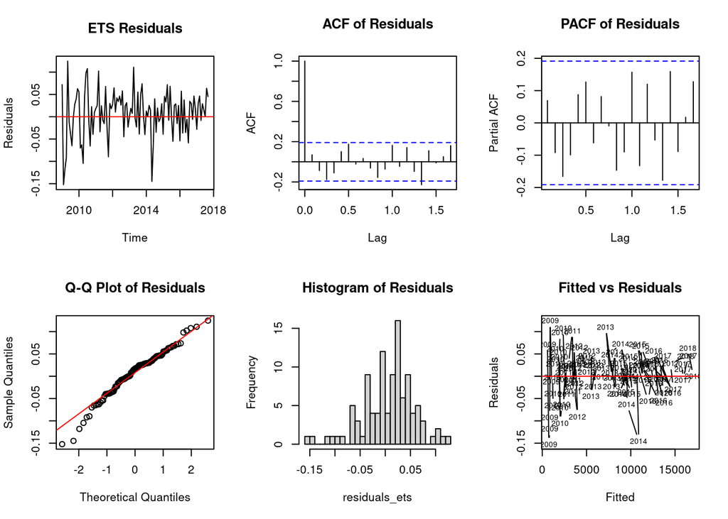

```r
# Residual analysis for ETS model
residuals_ets <- residuals(best_ets) # Assuming best_ets is your chosen ETS model (e.g., ets_auto)

par(mfrow = c(2, 3))

# 1. Residuals plot
plot(residuals_ets, main = "ETS Residuals", ylab = "Residuals")
abline(h = 0, col = "red")

# 2. ACF of residuals
acf(residuals_ets, main = "ACF of Residuals", na.action = na.pass)

# 3. PACF of residuals
pacf(residuals_ets, main = "PACF of Residuals", na.action = na.pass)

# 4. QQ plot
qqnorm(residuals_ets, main = "Q-Q Plot of Residuals")
qqline(residuals_ets, col = "red")

# 5. Histogram
hist(residuals_ets, main = "Histogram of Residuals", breaks = 20)

# 6. Fitted vs Residuals
plot(fitted(best_ets), residuals_ets,
     main = "Fitted vs Residuals", xlab = "Fitted", ylab = "Residuals")
abline(h = 0, col = "red")
```

```r
cat("Ljung-Box test for residual autocorrelation:\n")
```

```
## Ljung-Box test for residual autocorrelation:
```

```r
lb_test <- Box.test(residuals_ets, lag = 20, type = "Ljung-Box")
print(lb_test)
```

```
##
##  Box-Ljung test
##
## data:  residuals_ets
## X-squared = 33.63, df = 20, p-value = 0.02874
```

### 3.3 Model Comparison Summary

```r
cat("=== MODEL COMPARISON SUMMARY ===\n\n")
```

```
## === MODEL COMPARISON SUMMARY ===
```

```r
cat("Best SARIMA Model:\n")
```

```
## Best SARIMA Model:
```

```r
cat("Model:", paste(arimaorder(best_sarima), collapse = "-"), "\n")
```

```
## Model: 0-1-1-0-1-1-12
```

```r
cat("AIC:", best_sarima$aic, "\n")
```

```
## AIC: 415.1038
```

```r
cat("BIC:", best_sarima$bic, "\n\n")
```

```
## BIC: 422.6691
```

```r
cat("Best ETS Model:\n")
```

```
## Best ETS Model:
```

```r
cat("Model:", best_ets$method, "\n")
```

```
## Model: ETS(M,Ad,M)
```

```r
cat("AIC:", best_ets$aic, "\n")
```

```
## AIC: 1718.381
```

```r
cat("BIC:", best_ets$bic, "\n\n")
```

```
## BIC: 1766.152
```

```r
# Model selection recommendation
if (best_sarima$aic < best_ets$aic) {
  cat("RECOMMENDATION: SARIMA model has lower AIC and is preferred\n")
} else {
  cat("RECOMMENDATION: ETS model has lower AIC and is preferred\n")
}
```

```
## RECOMMENDATION: SARIMA model has lower AIC and is preferred
```

## 4. Future observations forecast

### 4.1 Forecast Generation

```r
# Set forecast horizon (length of test set)
h <- length(python_test)
cat("Forecast horizon:", h, "periods\n")
```

```
## Forecast horizon: 27 periods
```

```r
# Generate forecasts from best models
forecast_sarima <- forecast(best_sarima, h = h)
forecast_ets <- forecast(best_ets, h = h)
if (exists("lambda_bc") && abs(lambda_bc - 1) > 0.01) {
  cat("\nApplying inverse Box-Cox transformation to forecasts...\n")

  # Inverse transform SARIMA forecasts
  forecast_sarima$mean <- InvBoxCox(forecast_sarima$mean, lambda_bc)
  forecast_sarima$lower <- InvBoxCox(forecast_sarima$lower, lambda_bc)
  forecast_sarima$upper <- InvBoxCox(forecast_sarima$upper, lambda_bc)
  forecast_sarima$x <- python_train

  #forecast_ets$mean <- InvBoxCox(forecast_ets$mean, lambda_bc)
  #forecast_ets$lower <- InvBoxCox(forecast_ets$lower, lambda_bc)
  #forecast_ets$upper <- InvBoxCox(forecast_ets$upper, lambda_bc)
  #forecast_ets$x <- python_train
}
```

```
##
## Applying inverse Box-Cox transformation to forecasts...
```

```r
# Display forecast summaries
cat("\nSARIMA Forecast Summary:\n")
```

```
##
## SARIMA Forecast Summary:
```

```r
print(summary(forecast_sarima))
```

```
##
## Forecast method: ARIMA(0,1,1)(0,1,1)[12]
##
## Model Information:
## Series: train_ts
## ARIMA(0,1,1)(0,1,1)[12]
##
## Coefficients:
##           ma1     sma1
##       -0.1892  -0.6144
## s.e.   0.1082   0.1255
##
## sigma^2 = 4.8:  log likelihood = -204.55
## AIC=415.1   AICc=415.38   BIC=422.67
##
## Error measures:
##                    ME     RMSE      MAE     MPE    MAPE     MASE     ACF1
## Training set 7550.498 8949.028 7550.498 98.2411 98.2411 4.024532 0.961875
##
## Forecasts:
##          Point Forecast    Lo 80    Hi 80    Lo 95    Hi 95
## Oct 2017       18473.63 17643.03 19326.49 17212.29 19787.04
## Nov 2017       18785.63 17709.85 19898.40 17155.23 20502.56
## Dec 2017       17397.02 16185.67 18659.41 15564.87 19348.53
## Jan 2018       19019.61 17576.82 20528.89 16839.68 21355.04
## Feb 2018       19682.98 18059.88 21387.71 17233.32 22323.56
## Mar 2018       21707.53 19842.42 23670.60 18894.26 24749.90
## Apr 2018       20764.52 18817.27 22823.94 17831.26 23960.12
## May 2018       20624.62 18564.05 22812.12 17523.90 24022.21
## Jun 2018       20583.59 18411.82 22897.14 17318.69 24180.09
## Jul 2018       21379.98 19048.76 23868.84 17877.50 25251.14
## Aug 2018       21181.28 18759.07 23775.85 17545.47 25220.21
## Sep 2018       20592.76 18113.38 23258.61 16875.06 24746.57
## Oct 2018       22323.00 19512.76 25355.00 18113.27 27051.38
## Nov 2018       22671.10 19662.58 25930.99 18169.77 27760.30
## Dec 2018       21119.76 18081.30 24435.44 16582.73 26305.13
## Jan 2019       22932.00 19586.03 26587.99 17937.64 28651.41
## Feb 2019       23670.90 20111.65 27571.00 18362.47 29776.46
## Mar 2019       25919.54 22010.71 30203.90 20090.20 32627.13
## Apr 2019       24873.31 20919.60 29229.55 18985.81 31702.17
## May 2019       24717.93 20644.78 29222.63 18659.09 31786.01
## Jun 2019       24672.34 20474.55 29331.00 18434.30 31988.16
## Jul 2019       25556.35 21141.07 30464.72 18998.32 33267.50
## Aug 2019       25335.93 20821.08 30372.72 18636.84 33255.63
## Sep 2019       24682.54 20121.62 29792.64 17923.49 32725.88
## Oct 2019       26601.34 21617.12 32195.18 19218.61 35409.68
## Nov 2019       26986.62 21774.02 32859.05 19274.13 36242.13
## Dec 2019       25267.66 20089.21 31147.27 17623.11 34551.83
```

```r
cat("\nETS Forecast Summary:\n")
```

```
##
## ETS Forecast Summary:
```

```r
print(summary(forecast_ets))
```

```
##
## Forecast method: ETS(M,Ad,M)
##
## Model Information:
## ETS(M,Ad,M)
##
## Call:
## ets(y = train_ts)
##
##   Smoothing parameters:
##     alpha = 0.7452
##     beta  = 0.0571
##     gamma = 1e-04
##     phi   = 0.9799
##
##   Initial states:
##     l = 447.1339
##     b = 134.5046
##     s = 0.8902 1.0025 1.0081 0.9147 0.9842 1.0346
##            0.9885 1.0159 1.0238 1.1137 1.007 1.0168
##
##   sigma:  0.0568
##
##      AIC     AICc      BIC
## 1718.381 1726.335 1766.152
##
## Error measures:
##                    ME    RMSE      MAE       MPE     MAPE      MASE        ACF1
## Training set 68.75317 374.288 266.1051 0.4378172 4.111655 0.1418381 -0.08044851
##
## Forecasts:
##          Point Forecast    Lo 80    Hi 80     Lo 95    Hi 95
## Oct 2017       18770.68 17404.19 20137.16 16680.823 20860.53
## Nov 2017       18956.31 17196.46 20716.16 16264.849 21647.77
## Dec 2017       17084.47 15188.45 18980.49 14184.757 19984.18
## Jan 2018       19797.07 17261.94 22332.19 15919.932 23674.20
## Feb 2018       19880.31 17008.37 22752.25 15488.056 24272.56
## Mar 2018       22281.82 18707.46 25856.19 16815.299 27748.35
## Apr 2018       20750.77 17097.53 24404.01 15163.621 26337.92
## May 2018       20851.12 16858.99 24843.25 14745.679 26956.55
## Jun 2018       20535.30 16290.81 24779.79 14043.909 27026.69
## Jul 2018       21747.65 16924.11 26571.19 14370.684 29124.62
## Aug 2018       20926.03 15970.75 25881.31 13347.583 28504.48
## Sep 2018       19663.35 14713.55 24613.16 12093.275 27233.43
## Oct 2018       21903.18 16063.81 27742.54 12972.631 30833.72
## Nov 2018       22008.86 15815.04 28202.67 12536.234 31481.48
## Dec 2018       19740.54 13893.10 25587.98 10797.646 28683.43
## Jan 2019       22770.03 15688.96 29851.10 11940.465 33599.60
## Feb 2019       22765.50 15350.03 30180.97 11424.512 34106.48
## Mar 2019       25408.37 16757.49 34059.25 12177.986 38638.75
## Apr 2019       23567.22 15195.90 31938.54 10764.397 36370.04
## May 2019       23589.76 14862.79 32316.72 10243.019 36936.49
## Jun 2019       23146.37 14242.22 32050.52  9528.646 36764.09
## Jul 2019       24425.64 14669.08 34182.20  9504.272 39347.01
## Aug 2019       23422.49 13720.85 33124.12  8585.116 38259.85
## Sep 2019       21936.81 12526.37 31347.25  7544.779 36328.84
## Oct 2019       24358.32 13548.64 35167.99  7826.346 40890.29
## Nov 2019       24401.33 13211.01 35591.65  7287.214 41515.45
## Dec 2019       21822.27 11490.84 32153.70  6021.707 37622.84
```

### 4.2 Forecast Visualization with Confidence Intervals

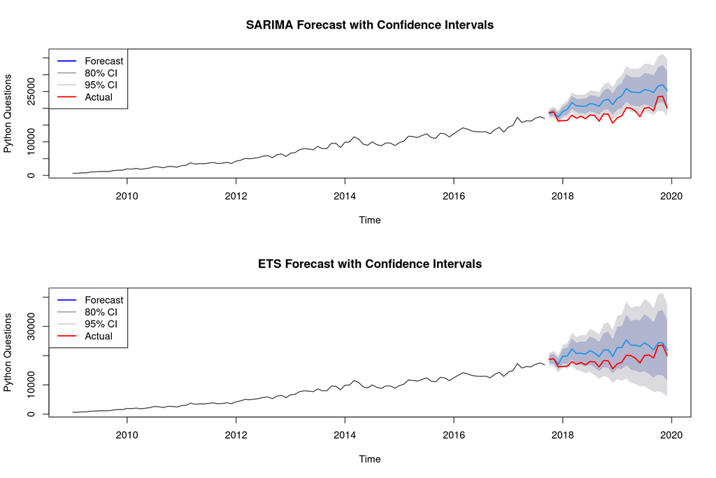

```r
# Create comprehensive forecast plots
par(mfrow = c(2, 1))

# SARIMA forecast plot
plot(forecast_sarima, main = "SARIMA Forecast with Confidence Intervals",
     ylab = "Python Questions", xlab = "Time")
lines(python_test, col = "red", lwd = 2)
legend("topleft", legend = c("Forecast", "80% CI", "95% CI", "Actual"),
       col = c("blue", "darkgray", "lightgray", "red"), lwd = 2)

# ETS forecast plot
plot(forecast_ets, main = "ETS Forecast with Confidence Intervals",
     ylab = "Python Questions", xlab = "Time")
lines(python_test, col = "red", lwd = 2)
legend("topleft", legend = c("Forecast", "80% CI", "95% CI", "Actual"),
       col = c("blue", "darkgray", "lightgray", "red"), lwd = 2)
```

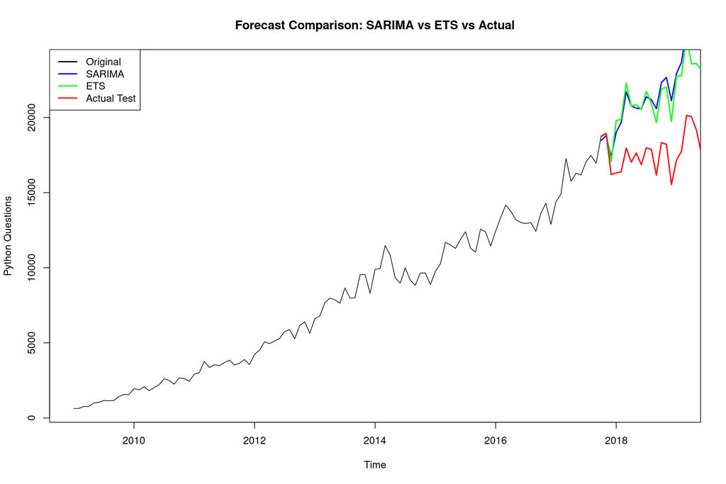

```r
par(mfrow = c(1, 1))
# Combined comparison plot
plot(python_ts, main = "Forecast Comparison: SARIMA vs ETS vs Actual",
     ylab = "Python Questions", xlab = "Time", xlim = c(2009, 2019))
lines(forecast_sarima$mean, col = "blue", lwd = 2)
lines(forecast_ets$mean, col = "green", lwd = 2)
lines(python_test, col = "red", lwd = 2)
legend("topleft", legend = c("Original", "SARIMA", "ETS", "Actual Test"),
       col = c("black", "blue", "green", "red"), lwd = 2)
```

### 4.3 Forecast Accuracy Analysis

```r
# Calculate accuracy measures
accuracy_sarima <- accuracy(forecast_sarima, python_test)
accuracy_ets <- accuracy(forecast_ets, python_test)

cat("=== FORECAST ACCURACY COMPARISON ===\n\n")
```

```
## === FORECAST ACCURACY COMPARISON ===
```

```r
cat("SARIMA Model Accuracy:\n")
```

```
## SARIMA Model Accuracy:
```

```r
print(accuracy_sarima)
```

```
##                     ME     RMSE      MAE       MPE     MAPE     MASE      ACF1 Theil's U
## Training set  7550.498 8949.028 7550.498  98.24110 98.24110 4.024532 0.9618750        NA
## Test set     -4037.425 4396.058 4067.850 -22.05036 22.21213 2.168227 0.7282897  2.646091
```

```r
cat("\nETS Model Accuracy:\n")
```

```
##
## ETS Model Accuracy:
```

```r
print(accuracy_ets)
```

```
##                       ME     RMSE       MAE         MPE      MAPE      MASE        ACF1 Theil's U
## Training set    68.75317  374.288  266.1051   0.4378172  4.111655 0.1418381 -0.08044851        NA
## Test set     -3259.20500 3608.251 3259.2050 -18.1208679 18.120868 1.7372066  0.70882234  2.251221
```

```r
# Extract test set accuracy (second row)
sarima_test_acc <- accuracy_sarima[2,]
ets_test_acc <- accuracy_ets[2,]

# Create comparison table
accuracy_comparison <- data.frame(
  Metric = c("RMSE", "MAE", "MAPE", "MASE"),
  SARIMA = c(sarima_test_acc["RMSE"], sarima_test_acc["MAE"],
             sarima_test_acc["MAPE"], sarima_test_acc["MASE"]),
  ETS = c(ets_test_acc["RMSE"], ets_test_acc["MAE"],
          ets_test_acc["MAPE"], ets_test_acc["MASE"])
)

cat("\nAccuracy Metrics Comparison:\n")
```

```
##
## Accuracy Metrics Comparison:
```

```r
print(accuracy_comparison)
```

```
##      Metric      SARIMA         ETS
## RMSE   RMSE 4396.057693 3608.250652
## MAE     MAE 4067.850379 3259.205002
## MAPE   MAPE   22.212133   18.120868
## MASE   MASE    2.168227    1.737207
```

```r
# Determine best model based on RMSE
best_model_name <- if (sarima_test_acc["RMSE"] < ets_test_acc["RMSE"]) "SARIMA" else "ETS"
cat("\nBest forecasting model based on RMSE:", best_model_name, "\n")
```

```
##
## Best forecasting model based on RMSE: ETS
```

### 4.4 Confidence Interval Analysis

```r
# Extract confidence intervals
sarima_lower80 <- forecast_sarima$lower[, "80%"]
sarima_upper80 <- forecast_sarima$upper[, "80%"]
sarima_lower95 <- forecast_sarima$lower[, "95%"]
sarima_upper95 <- forecast_sarima$upper[, "95%"]

ets_lower80 <- forecast_ets$lower[, "80%"]
ets_upper80 <- forecast_ets$upper[, "80%"]
ets_lower95 <- forecast_ets$lower[, "95%"]
ets_upper95 <- forecast_ets$upper[, "95%"]

# Check coverage probability
actual_values <- as.numeric(python_test)
sarima_forecasts <- as.numeric(forecast_sarima$mean)
ets_forecasts <- as.numeric(forecast_ets$mean)

# Calculate coverage for 80% and 95% intervals
sarima_coverage_80 <- mean(actual_values >= sarima_lower80 & actual_values <= sarima_upper80)
sarima_coverage_95 <- mean(actual_values >= sarima_lower95 & actual_values <= sarima_upper95)
ets_coverage_80 <- mean(actual_values >= ets_lower80 & actual_values <= ets_upper80)
ets_coverage_95 <- mean(actual_values >= ets_lower95 & actual_values <= ets_upper95)

cat("=== CONFIDENCE INTERVAL COVERAGE ===\n\n")
```

```
## === CONFIDENCE INTERVAL COVERAGE ===
```

```r
cat("SARIMA Model:\n")
```

```
## SARIMA Model:
```

```r
cat("80% CI Coverage:", round(sarima_coverage_80 * 100, 1), "%\n")
```

```
## 80% CI Coverage: 18.5 %
```

```r
cat("95% CI Coverage:", round(sarima_coverage_95 * 100, 1), "%\n\n")
```

```
## 95% CI Coverage: 63 %
```

```r
cat("ETS Model:\n")
```

```
## ETS Model:
```

```r
cat("80% CI Coverage:", round(ets_coverage_80 * 100, 1), "%\n")
```

```
## 80% CI Coverage: 85.2 %
```

```r
cat("95% CI Coverage:", round(ets_coverage_95 * 100, 1), "%\n")
```

```
## 95% CI Coverage: 100 %
```

```r
# Calculate average interval width
sarima_width_80 <- mean(sarima_upper80 - sarima_lower80)
sarima_width_95 <- mean(sarima_upper95 - sarima_lower95)
ets_width_80 <- mean(ets_upper80 - ets_lower80)
ets_width_95 <- mean(ets_upper95 - ets_lower95)

cat("\n=== AVERAGE INTERVAL WIDTHS ===\n\n")
```

```
##
## === AVERAGE INTERVAL WIDTHS ===
```

```r
cat("SARIMA Model:\n")
```

```
## SARIMA Model:
```

```r
cat("80% CI Average Width:", round(sarima_width_80, 2), "\n")
```

```
## 80% CI Average Width: 6381.74
```

```r
cat("95% CI Average Width:", round(sarima_width_95, 2), "\n\n")
```

```
## 95% CI Average Width: 9765.42
```

```r
cat("ETS Model:\n")
```

```
## ETS Model:
```

```r
cat("80% CI Average Width:", round(ets_width_80, 2), "\n")
```

```
## 80% CI Average Width: 12507.62
```

```r
cat("95% CI Average Width:", round(ets_width_95, 2), "\n")
```

```
## 95% CI Average Width: 19128.75
```

### 4.5 Bootstrap Forecast Methodology

```r
# Bootstrap forecast for uncertainty quantification
set.seed(123)  # For reproducibility

# Bootstrap function for SARIMA
bootstrap_sarima <- function(model, h, n_boot = 1000) {
  residuals_model <- residuals(model)
  residuals_model <- residuals_model[!is.na(residuals_model)]

  # Store bootstrap forecasts
  boot_forecasts <- matrix(NA, nrow = n_boot, ncol = h)

  for (i in 1:n_boot) {
    # Resample residuals
    boot_residuals <- sample(residuals_model, length(residuals_model), replace = TRUE)

    # Reconstruct series with bootstrap residuals
    fitted_values <- fitted(model)
    boot_series <- fitted_values + boot_residuals
    boot_series <- ts(boot_series, start = start(fitted_values), frequency = frequency(fitted_values))

    # Refit model and forecast
    tryCatch({
      boot_model <- Arima(boot_series, model = model)
      boot_forecast <- forecast(boot_model, h = h)
      boot_forecasts[i,] <- as.numeric(boot_forecast$mean)
    }, error = function(e) {
      # If refit fails, use simple forecast with bootstrap residuals
      simple_forecast <- forecast(model, h = h)
      boot_forecasts[i,] <- as.numeric(simple_forecast$mean) +
        sample(residuals_model, h, replace = TRUE)
    })
  }

  return(boot_forecasts)
}

cat("Performing bootstrap forecast analysis...\n")
```

```
## Performing bootstrap forecast analysis...
```

```r
cat("This may take a few moments...\n")
```

```
## This may take a few moments...
```

```r
# Perform bootstrap (reduced iterations for computational efficiency)
n_bootstrap <- 500
boot_forecasts_sarima <- bootstrap_sarima(best_sarima, h, n_bootstrap)

if (exists("lambda_bc") && abs(lambda_bc - 1) > 0.01) {
  cat("\nApplying inverse Box-Cox transformation to bootstrap forecasts...\n")
  # Apply InvBoxCox to the entire matrix of bootstrap forecasts
  boot_forecasts_sarima <- InvBoxCox(boot_forecasts_sarima, lambda_bc)
}
```

```
##
## Applying inverse Box-Cox transformation to bootstrap forecasts...
```

```r
# Calculate bootstrap confidence intervals
boot_lower_80 <- apply(boot_forecasts_sarima, 2, quantile, probs = 0.1, na.rm = TRUE)
boot_upper_80 <- apply(boot_forecasts_sarima, 2, quantile, probs = 0.9, na.rm = TRUE)
boot_lower_95 <- apply(boot_forecasts_sarima, 2, quantile, probs = 0.025, na.rm = TRUE)
boot_upper_95 <- apply(boot_forecasts_sarima, 2, quantile, probs = 0.975, na.rm = TRUE)
boot_mean <- apply(boot_forecasts_sarima, 2, mean, na.rm = TRUE)

# Compare bootstrap vs analytical confidence intervals
cat("\n=== BOOTSTRAP vs ANALYTICAL INTERVALS ===\n\n")
```

```
##
## === BOOTSTRAP vs ANALYTICAL INTERVALS ===
```

```r
# Coverage comparison
boot_coverage_80 <- mean(actual_values >= boot_lower_80 & actual_values <= boot_upper_80)
boot_coverage_95 <- mean(actual_values >= boot_lower_95 & actual_values <= boot_upper_95)

cat("Bootstrap Coverage:\n")
```

```
## Bootstrap Coverage:
```

```r
cat("80% CI Coverage:", round(boot_coverage_80 * 100, 1), "%\n")
```

```
## 80% CI Coverage: 3.7 %
```

```r
cat("95% CI Coverage:", round(boot_coverage_95 * 100, 1), "%\n\n")
```

```
## 95% CI Coverage: 18.5 %
```

```r
cat("Analytical Coverage (SARIMA):\n")
```

```
## Analytical Coverage (SARIMA):
```

```r
cat("80% CI Coverage:", round(sarima_coverage_80 * 100, 1), "%\n")
```

```
## 80% CI Coverage: 18.5 %
```

```r
cat("95% CI Coverage:", round(sarima_coverage_95 * 100, 1), "%\n")
```

```
## 95% CI Coverage: 63 %
```

```r
# Width comparison
boot_width_80 <- mean(boot_upper_80 - boot_lower_80)
boot_width_95 <- mean(boot_upper_95 - boot_lower_95)

cat("\nBootstrap Interval Widths:\n")
```

```
##
## Bootstrap Interval Widths:
```

```r
cat("80% CI Average Width:", round(boot_width_80, 2), "\n")
```

```
## 80% CI Average Width: 2192.49
```

```r
cat("95% CI Average Width:", round(boot_width_95, 2), "\n\n")
```

```
## 95% CI Average Width: 3435.25
```

```r
cat("Analytical Interval Widths (SARIMA):\n")
```

```
## Analytical Interval Widths (SARIMA):
```

```r
cat("80% CI Average Width:", round(sarima_width_80, 2), "\n")
```

```
## 80% CI Average Width: 6381.74
```

```r
cat("95% CI Average Width:", round(sarima_width_95, 2), "\n")
```

```
## 95% CI Average Width: 9765.42
```

### 4.6 Bootstrap Forecast Visualization

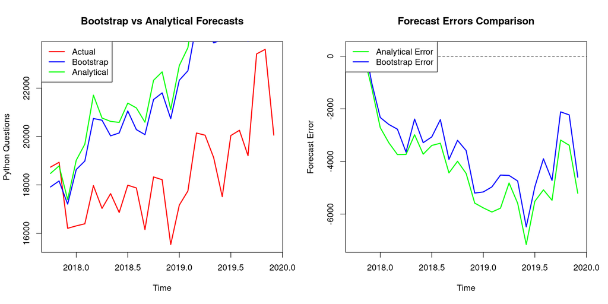

```r
# Plot bootstrap results with robust error handling
tryCatch({
  par(mfrow = c(1, 2))

  # Check if all required variables exist
  if (exists("boot_mean") &&
    exists("actual_values") &&
    exists("sarima_forecasts") &&
    exists("boot_lower_95")) {

    # Convert to numeric vectors to avoid time series issues
    time_vals <- as.numeric(time(python_test))
    actual_vals <- as.numeric(actual_values)
    boot_vals <- as.numeric(boot_mean)
    sarima_vals <- as.numeric(sarima_forecasts)

    # Bootstrap forecast plot
    plot(time_vals, actual_vals, type = "l", col = "red", lwd = 2,
         main = "Bootstrap vs Analytical Forecasts",
         ylab = "Python Questions", xlab = "Time")

    # Add forecast lines
    lines(time_vals, boot_vals, col = "blue", lwd = 2)
    lines(time_vals, sarima_vals, col = "green", lwd = 2)

    # Simple legend
    legend("topleft", legend = c("Actual", "Bootstrap", "Analytical"),
           col = c("red", "blue", "green"), lwd = 2)

    # Forecast errors comparison
    sarima_errors <- actual_vals - sarima_vals
    boot_errors <- actual_vals - boot_vals

    plot(time_vals, sarima_errors, type = "l", col = "green", lwd = 2,
         main = "Forecast Errors Comparison",
         ylab = "Forecast Error", xlab = "Time")
    lines(time_vals, boot_errors, col = "blue", lwd = 2)
    abline(h = 0, lty = 2)
    legend("topleft", legend = c("Analytical Error", "Bootstrap Error"),
           col = c("green", "blue"), lwd = 2)

  } else {
    cat("Bootstrap results not available for plotting\n")
    plot.new()
    text(0.5, 0.5, "Bootstrap analysis not completed", cex = 1.5)
    plot.new()
    text(0.5, 0.5, "Error analysis not available", cex = 1.5)
  }

  par(mfrow = c(1, 1))

}, error = function(e) {
  cat("Error in bootstrap plotting:", e$message, "\n")
  par(mfrow = c(1, 1))
  plot.new()
  text(0.5, 0.5, "Bootstrap plotting failed", cex = 1.5)
})
```

### 4.7 Forecast Performance Summary

```r
cat("=== COMPREHENSIVE FORECAST PERFORMANCE SUMMARY ===\n\n")
```

```
## === COMPREHENSIVE FORECAST PERFORMANCE SUMMARY ===
```

```r
# RMSE comparison
rmse_sarima <- sqrt(mean((actual_values - sarima_forecasts)^2))
rmse_ets <- sqrt(mean((actual_values - ets_forecasts)^2))
rmse_bootstrap <- sqrt(mean((actual_values - boot_mean)^2))

cat("Root Mean Square Error (RMSE):\n")
```

```
## Root Mean Square Error (RMSE):
```

```r
cat("SARIMA:", round(rmse_sarima, 2), "\n")
```

```
## SARIMA: 4396.06
```

```r
cat("ETS:", round(rmse_ets, 2), "\n")
```

```
## ETS: 3608.25
```

```r
cat("Bootstrap:", round(rmse_bootstrap, 2), "\n\n")
```

```
## Bootstrap: 3762.27
```

```r
# MAE comparison
mae_sarima <- mean(abs(actual_values - sarima_forecasts))
mae_ets <- mean(abs(actual_values - ets_forecasts))
mae_bootstrap <- mean(abs(actual_values - boot_mean))

cat("Mean Absolute Error (MAE):\n")
```

```
## Mean Absolute Error (MAE):
```

```r
cat("SARIMA:", round(mae_sarima, 2), "\n")
```

```
## SARIMA: 4067.85
```

```r
cat("ETS:", round(mae_ets, 2), "\n")
```

```
## ETS: 3259.21
```

```r
cat("Bootstrap:", round(mae_bootstrap, 2), "\n\n")
```

```
## Bootstrap: 3478.71
```

```r
# Overall best model
best_overall <- which.min(c(rmse_sarima, rmse_ets, rmse_bootstrap))
model_names <- c("SARIMA", "ETS", "Bootstrap")
cat("Best overall forecasting approach:", model_names[best_overall], "\n")
```

```
## Best overall forecasting approach: ETS
```

```r
# Create final comparison table with error handling
tryCatch({
  # Check if bootstrap results exist
  if (exists("rmse_bootstrap") &&
    exists("mae_bootstrap") &&
    exists("boot_coverage_80")) {
    final_comparison <- data.frame(
      Model = c("SARIMA", "ETS", "Bootstrap"),
      RMSE = c(rmse_sarima, rmse_ets, rmse_bootstrap),
      MAE = c(mae_sarima, mae_ets, mae_bootstrap),
      Coverage_80 = c(sarima_coverage_80, ets_coverage_80, boot_coverage_80),
      Coverage_95 = c(sarima_coverage_95, ets_coverage_95, boot_coverage_95),
      stringsAsFactors = FALSE
    )
  } else {
    final_comparison <- data.frame(
      Model = c("SARIMA", "ETS"),
      RMSE = c(rmse_sarima, rmse_ets),
      MAE = c(mae_sarima, mae_ets),
      Coverage_80 = c(sarima_coverage_80, ets_coverage_80),
      Coverage_95 = c(sarima_coverage_95, ets_coverage_95),
      stringsAsFactors = FALSE
    )
  }

  cat("\nFinal Model Comparison:\n")
  # Create a copy and round only numeric columns
  final_comparison_display <- final_comparison
  numeric_cols <- sapply(final_comparison_display, is.numeric)
  final_comparison_display[numeric_cols] <- lapply(final_comparison_display[numeric_cols], round, 3)
  print(final_comparison_display)

}, error = function(e) {
  cat("Error creating final comparison table:", e$message, "\n")
  cat("Displaying individual results:\n")
  cat("SARIMA RMSE:", round(rmse_sarima, 3), "\n")
  cat("ETS RMSE:", round(rmse_ets, 3), "\n")
  if (exists("rmse_bootstrap")) {
    cat("Bootstrap RMSE:", round(rmse_bootstrap, 3), "\n")
  }
})
```

```
##
## Final Model Comparison:
##       Model     RMSE      MAE Coverage_80 Coverage_95
## 1    SARIMA 4396.058 4067.850       0.185       0.630
## 2       ETS 3608.251 3259.205       0.852       1.000
## 3 Bootstrap 3762.270 3478.709       0.037       0.185
```